# Peer_assignment_1

GabriellaJacoel

16 luglio 2017

## Daily Activity Analysis

First of all, I import the data through function ‘read.csv’ and I convert the data.frame into data.table, for simplicity.

```r
library(data.table)
setwd("C:/Users/GJacoel/Desktop/Coursera/Reproducible Research/Week2/")
activity<-read.csv("activity.csv")
activity<-as.data.table(activity)
daily_activity<-activity[,list(daily_step=sum(steps,na.rm = T)),by=date]
```

Then, I aggregate data, summing up the number of steps for each day.

```r
daily_activity<-activity[,list(daily_step=sum(steps,na.rm = T)),by=date]
```

[figure not shown]

```r
daily_mean<-mean(daily_activity$daily_step)
daily_median<-median(daily_activity$daily_step)
```

Mean of distribution is 9354.2295082. Median of distribution is 10395

## Average daily activity pattern

I compute the average number of steps for each 5 minute interval, evaluated over all the days at our disposal:

```r
av_daily_activity<-activity[,list(av_step=mean(steps,na.rm = T)),by=interval]
```

Then, we plot the computed points on a line-plot, that shows the average pattern of daily activity:

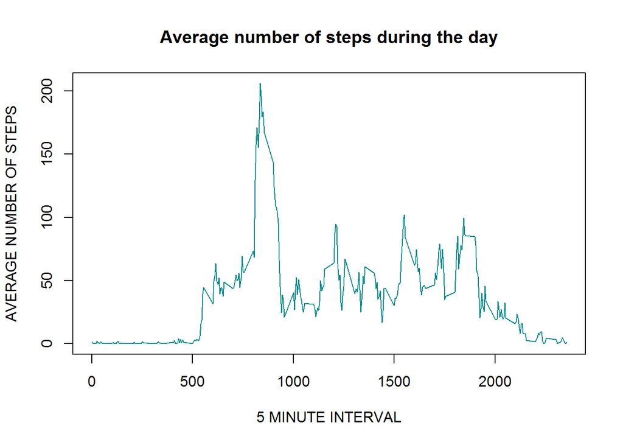

```r
plot(y=av_daily_activity$av_step,x = av_daily_activity$interval,type = "l",col="darkcyan",xlab = "5 MINUTE INTERVAL",ylab = "AVERAGE NUMBER OF STEPS",main = "Average number of steps during the day")
```

## Missing values analysis

```r
x<-sapply(activity,function(x) sum(is.na(x)))
```

Total number of missing values in the dataset is 2304. We replace all the missing values concentrated on “Steps” column, with the average number of steps calculated in the above analysis:

```r
no_na_activity<-merge(x=activity,y=av_daily_activity, by=c("interval"),all.x = T)
no_na_activity$steps<-as.numeric(no_na_activity$steps)
no_na_activity[is.na(no_na_activity$steps),]$steps<-no_na_activity[is.na(no_na_activity$steps),]$av_step
```

Now we recompute the daily analysis, using the new imputed values:

```r
no_na_daily_activity<-no_na_activity[,list(daily_step=sum(steps,na.rm = T)),by=date]
```

In order to study daily steps distribution, we plot the histogram of steps.

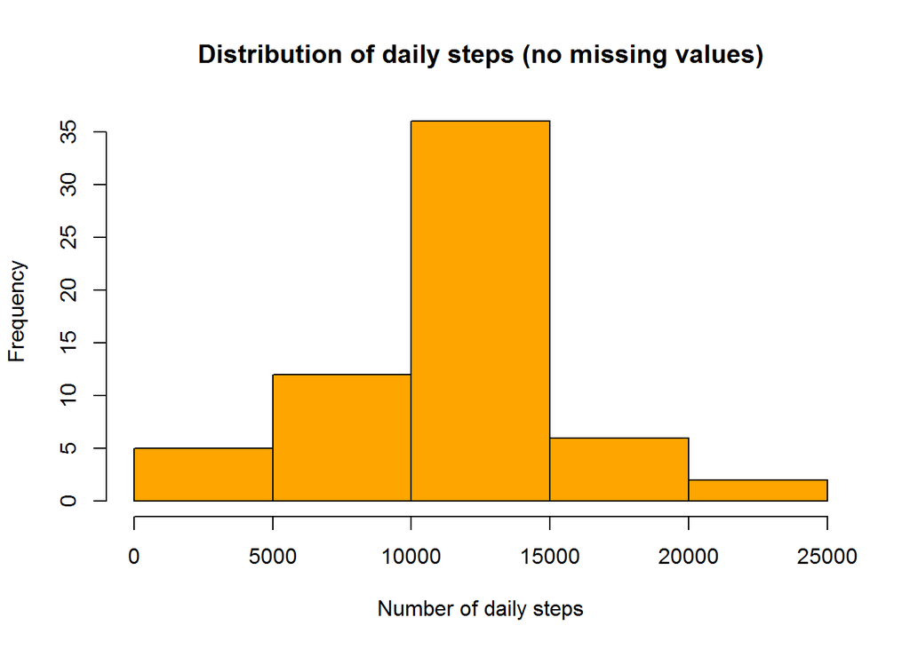

```r
hist (no_na_daily_activity$daily_step,col = "orange",xlab ="Number of daily steps", main ="Distribution of daily steps (no missing values)")
```

```r
no_na_daily_mean<-mean(no_na_daily_activity$daily_step)
no_na_daily_median<-median(no_na_daily_activity$daily_step)
```

## Analysis weekend/weekdays activity

We classify each date as “Weekend” or “Weekday” to perform the analysis:

```r
no_na_activity$date<-as.Date(no_na_activity$date)
no_na_activity$weekdays<-weekdays(no_na_activity$date)
no_na_activity$weekend<-"Weekday"
no_na_activity[no_na_activity$weekdays=="sabato"|no_na_activity$weekdays=="domenica",]$weekend<-"Weekend"
no_na_activity$weekdays<-NULL

no_na_av_daily_activity<-no_na_activity[,list(av_step=mean(steps,na.rm = T)),by=c("interval","weekend")]
weekend_activity<-no_na_av_daily_activity[weekend=="Weekend"]
weekday_activity<-no_na_av_daily_activity[weekend=="Weekday"]
```

Now we plot the results:

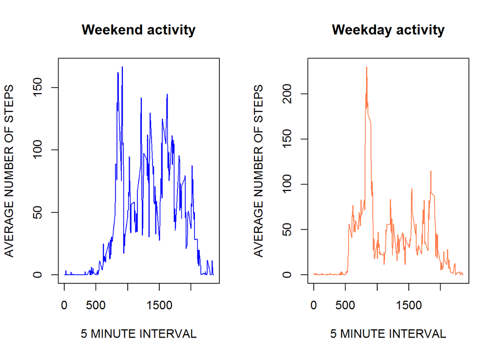

```r
par(mfrow=c(1,2))
plot(y=weekend_activity$av_step,x = weekend_activity$interval,type = "l",col="blue",xlab = "5 MINUTE INTERVAL",ylab = "AVERAGE NUMBER OF STEPS", main="Weekend activity")
plot(y=weekday_activity$av_step,x = weekday_activity$interval,type = "l",col="coral",xlab = "5 MINUTE INTERVAL",ylab = "AVERAGE NUMBER OF STEPS", main="Weekday activity")
```